# Data Analysis and Visualization

## Data Analysis

- A credible amount of data has to be collected to allow for a substantial analysis
- Information collected must now be described, analyzed and interpreted
- Look beyond the raw data to ask important questions about what the results mean and whether they are significant
- Check the data to ensure that it is "clean" and look for inconsistencies

## Types of Method

- Quantitative data produces numerical values
- Qualitative data produces narratives

## Setting up a working environment

- Download Anaconda: https://www.anaconda.com/distribution/#download-section (For any OS)
- After installing anaconda, open COMMAND PROMPT (or WINDOWS+R)
- Run **jupyter notebook**
- Install Python3.x version

[figure not shown]

# With Python

[figure not shown]

# Python is...

- Widespread
- Reproducible
- Multi-functional
- Open Source

## Explore Forest Fires in Brazil

Based on the dataset from http://dados.gov.br/dataset/sistema-nacional-de-informacoes-florestais-snif

## Import libraries and prepare the data

```python
!pip install matplotlib seaborn # To install pandas/numpy, run pip install numpy pandas

import pandas as pd
import numpy as np
import matplotlib.pyplot as plt
%matplotlib inline
import seaborn as sns

data = pd.read_csv('/Users/amitkumarjaiswal/Documents/PGRForum/amazon.csv', encoding='latin1')
data.head()
```

```
     |████████████████████████████████| 215kB 3.5MB/s eta 0:00:01
```

|  | year | state | month | number | date |
| --- | --- | --- | --- | --- | --- |
| 0 | 1998 | Acre | Janeiro | 0.0 | 1998-01-01 |
| 1 | 1999 | Acre | Janeiro | 0.0 | 1999-01-01 |
| 2 | 2000 | Acre | Janeiro | 0.0 | 2000-01-01 |
| 3 | 2001 | Acre | Janeiro | 0.0 | 2001-01-01 |
| 4 | 2002 | Acre | Janeiro | 0.0 | 2002-01-01 |

```python
# Check the overview of dataset
data.describe()
```

|  | year | number |
| --- | --- | --- |
| count | 6454.000000 | 6454.000000 |
| mean | 2007.461729 | 108.293163 |
| std | 5.746654 | 190.812242 |
| min | 1998.000000 | 0.000000 |
| 25% | 2002.000000 | 3.000000 |
| 50% | 2007.000000 | 24.000000 |
| 75% | 2012.000000 | 113.000000 |
| max | 2017.000000 | 998.000000 |

```python
# Check missing data
data.isna().sum()
```

```
year      0
state     0
month     0
number    0
date      0
dtype: int64
```

```python
# Check unique values in the state column
data.state.unique()
```

```
array(['Acre', 'Alagoas', 'Amapa', 'Amazonas', 'Bahia', 'Ceara',
       'Distrito Federal', 'Espirito Santo', 'Goias', 'Maranhao',
       'Mato Grosso', 'Minas Gerais', 'Pará', 'Paraiba', 'Pernambuco',
       'Piau', 'Rio', 'Rondonia', 'Roraima', 'Santa Catarina',
       'Sao Paulo', 'Sergipe', 'Tocantins'], dtype=object)
```

```python
# Check unique values in the month column
data.month.unique()
```

```
array(['Janeiro', 'Fevereiro', 'Março', 'Abril', 'Maio', 'Junho', 'Julho',
       'Agosto', 'Setembro', 'Outubro', 'Novembro', 'Dezembro'],
      dtype=object)
```

```python
# Update data for understability

data['month'].replace(to_replace = 'Janeiro', value = 'Jan', inplace = True)
data['month'].replace(to_replace = 'Fevereiro', value = 'Feb', inplace = True)
data['month'].replace(to_replace = 'Março', value = 'Mar', inplace = True)
data['month'].replace(to_replace = 'Abril', value = 'Apr', inplace = True)
data['month'].replace(to_replace = 'Maio', value = 'May', inplace = True)
data['month'].replace(to_replace = 'Junho', value = 'Jun', inplace = True)
data['month'].replace(to_replace = 'Julho', value = 'Jul', inplace = True)
data['month'].replace(to_replace = 'Agosto', value = 'Aug', inplace = True)
data['month'].replace(to_replace = 'Setembro', value = 'Sep', inplace = True)
data['month'].replace(to_replace = 'Outubro', value = 'Oct', inplace = True)
data['month'].replace(to_replace = 'Novembro', value = 'Nov', inplace = True)
data['month'].replace(to_replace = 'Dezembro', value = 'Dec', inplace = True)
```

```python
year_mo_state = data.groupby(by = ['year','state', 'month']).sum().reset_index()
```

# Visualization

- Inspirational (e.g.: art, media)
- Explanatory (e.g.: education, journalism)
- Analytical (e.g.: data science)

# How does Interactive Data Analysis work?

[figure not shown]

- Problem + Questions
- Data Gathering
- Data Transformation/Querying
- Modeling and Visualization
- Interpretation
- Knowledge + Questions

## Visualize data

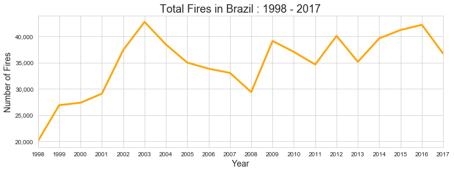

```python
sns.set_style('whitegrid')
from matplotlib.pyplot import MaxNLocator, FuncFormatter

plt.figure(figsize=(12,4))

ax = sns.lineplot(x = 'year', y = 'number', data = year_mo_state, estimator = 'sum', color = 'orange', lw = 3,
                  err_style = None)

plt.title('Total Fires in Brazil : 1998 - 2017', fontsize = 18)
plt.xlabel('Year', fontsize = 14)
plt.ylabel('Number of Fires', fontsize = 14)

ax.xaxis.set_major_locator(plt.MaxNLocator(19))
ax.set_xlim(1998, 2017)

ax.get_yaxis().set_major_formatter(plt.FuncFormatter(lambda x, p: format(int(x), ',')))
```

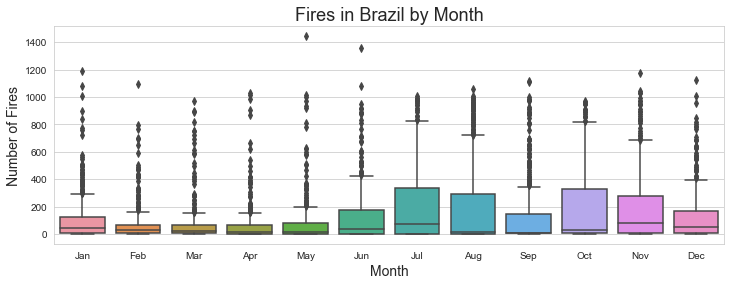

```python
plt.figure(figsize=(12,4))

sns.boxplot(x = 'month', order = ['Jan', 'Feb', 'Mar', 'Apr', 'May', 'Jun', 'Jul', 'Aug', 'Sep','Oct', 'Nov', 'Dec'],
            y = 'number', data = year_mo_state)

plt.title('Fires in Brazil by Month', fontsize = 18)
plt.xlabel('Month', fontsize = 14)
plt.ylabel('Number of Fires', fontsize = 14)
```

## Fire in Amazon State

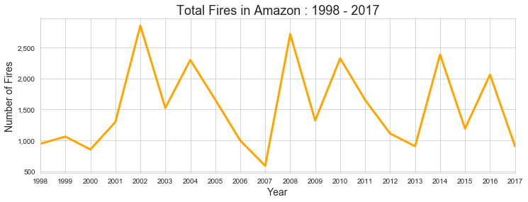

```python
year_mo_state_Amazon = data[data['state'] == 'Amazonas'].groupby(by = ['year','state', 'month']).sum().reset_index()

plt.figure(figsize=(12,4))

ax = sns.lineplot(x = 'year', y = 'number', data = year_mo_state_Amazon, estimator = 'sum', color = 'orange', lw = 3,
                  err_style = None)

plt.title('Total Fires in Amazon : 1998 - 2017', fontsize = 18)
plt.xlabel('Year', fontsize = 14)
plt.ylabel('Number of Fires', fontsize = 14)

ax.xaxis.set_major_locator(plt.MaxNLocator(19))
ax.set_xlim(1998, 2017)

ax.get_yaxis().set_major_formatter(plt.FuncFormatter(lambda x, p: format(int(x), ',')))
```

```python
#But, if we look more closely to the dataset, Amazon isn't by far
#the place where most of the fires in Brazil occure.
#Top 3 states are Mato Grosso (an outlier, with a total sum of wildfires in the analysed period of 96k),
#followed by Paraiba (52k) and Sao Paulo (51k). Amazon has the 10th place in this ranking

data.groupby(by = 'state')['number'].sum().sort_values(ascending = False).head(10)
```

```
state
Mato Grosso     96246.028
Paraiba         52435.918
Sao Paulo       51121.198
Rio             45160.865
Bahia           44746.226
Piau            37803.747
Goias           37695.520
Minas Gerais    37475.258
Tocantins       33707.885
Amazonas        30650.129
Name: number, dtype: float64
```

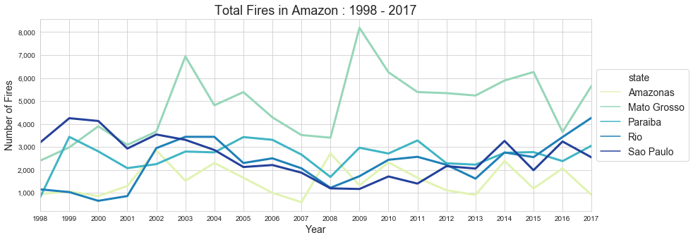

```python
year_mo_state_top_states = data[data['state'].isin(['Amazonas','Mato Grosso','Paraiba','Sao Paulo','Rio'])].groupby(by = ['year','state', 'month']).sum().reset_index()

plt.figure(figsize=(14,5))

ax = sns.lineplot(x = 'year', y = 'number', data = year_mo_state_top_states, hue = 'state', estimator = 'sum', color = 'orange', lw = 3,
                  err_style = None, palette = 'YlGnBu')

plt.title('Total Fires in Amazon : 1998 - 2017', fontsize = 18)
plt.xlabel('Year', fontsize = 14)
plt.ylabel('Number of Fires', fontsize = 14)

ax.xaxis.set_major_locator(plt.MaxNLocator(19))
ax.set_xlim(1998, 2017)

ax.get_yaxis().set_major_formatter(plt.FuncFormatter(lambda x, p: format(int(x), ',')))
ax.legend(loc='center left', bbox_to_anchor=(1, 0.5), prop={'size': 14})
```

```python
!pip install plotly wordcloud
import plotly as py
from plotly.offline import init_notebook_mode, iplot, plot

init_notebook_mode(connected=True)
import plotly.graph_objs as go

# word cloud library
from wordcloud import WordCloud
```

```
     |████████████████████████████████| 163kB 3.0MB/s eta 0:00:01
```

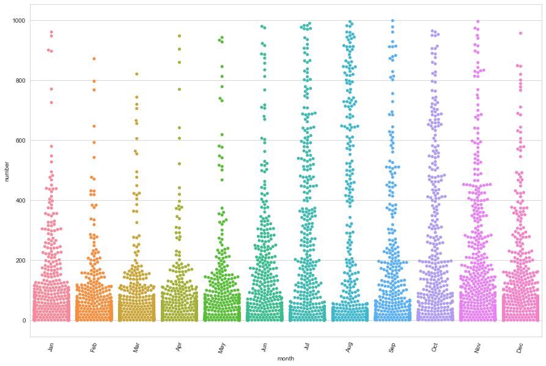

```python
plt.figure(figsize=(15,10))
sns.swarmplot(x="month", y="number",data=data)
plt.xticks(rotation=75)
plt.show()
```

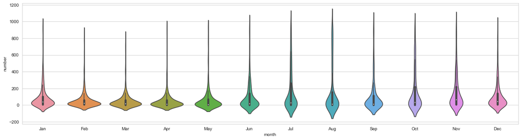

```python
fig=plt.figure(figsize=(20,5))
sns.violinplot(x="month",y="number",data=data)
plt.show()
```

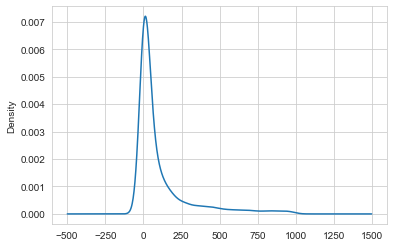

```python
ax=data.number.plot.kde()
```

```python
from plotly import tools
# prepare data frames
df2017 = data[data.year == 2017].iloc[:100,:]

y_saving = [each for each in df2017.number]
y_net_worth  = [float(each) for each in df2017.number]
x_saving = [each for each in df2017.state]
x_net_worth  = [each for each in df2017.state]
trace0 = go.Bar(
                x=y_saving,
                y=x_saving,
                marker=dict(color='rgba(171, 50, 96, 0.6)',line=dict(color='rgba(171, 50, 96, 1.0)',width=1)),
                name='number',
                orientation='h',
)
trace1 = go.Scatter(
                x=y_net_worth,
                y=x_net_worth,
                mode='lines+markers',
                line=dict(color='rgb(63, 72, 204)'),
                name='state',
)
layout = dict(
                title='number and state',
                yaxis=dict(showticklabels=True,domain=[0, 0.85]),
                yaxis2=dict(showline=True,showticklabels=False,linecolor='rgba(102, 102, 102, 0.8)',linewidth=2,domain=[0, 0.85]),
                xaxis=dict(zeroline=False,showline=False,showticklabels=True,showgrid=True,domain=[0, 0.42]),
                xaxis2=dict(zeroline=False,showline=False,showticklabels=True,showgrid=True,domain=[0.47, 1],side='top',dtick=25),
                legend=dict(x=0.029,y=1.038,font=dict(size=10) ),
                margin=dict(l=200, r=20,t=70,b=70),
                paper_bgcolor='rgb(248, 248, 255)',
                plot_bgcolor='rgb(248, 248, 255)',
)
annotations = []
y_s = np.round(y_saving, decimals=2)
y_nw = np.rint(y_net_worth)
# Adding labels
for ydn, yd, xd in zip(y_nw, y_s, x_saving):
    # labeling the scatter savings
    annotations.append(dict(xref='x2', yref='y2', y=xd, x=ydn - 4,text='{:,}'.format(ydn),font=dict(family='Arial', size=12,color='rgb(63, 72, 204)'),showarrow=False))
    # labeling the bar net worth
    annotations.append(dict(xref='x1', yref='y1', y=xd, x=yd + 3,text=str(yd),font=dict(family='Arial', size=12,color='rgb(171, 50, 96)'),showarrow=False))

layout['annotations'] = annotations

# Creating two subplots
fig = tools.make_subplots(rows=1, cols=2, specs=[[{}, {}]], shared_xaxes=True,
                          shared_yaxes=False, vertical_spacing=0.001)

fig.append_trace(trace0, 1, 1)
fig.append_trace(trace1, 1, 2)

fig['layout'].update(layout)
iplot(fig)
```

[interactive chart not shown]

```python
df2017 = data[data.year == 2017].iloc[:100,:]
pie1 = df2017.number
labels = df2017.state
# figure
fig = {
  "data": [
    {
      "values": pie1,
      "labels": labels,
      "domain": {"x": [0, .5]},
      "name": "Number Of Fires",
      "hoverinfo":"label+percent+name",
      "hole": .3,
      "type": "pie"
    },],
  "layout": {
        "title":"States Number of Fires",
        "annotations": [
            { "font": { "size": 20},
              "showarrow": False,
              "text": "Number of Fires",
                "x": 0.20,
                "y": 1
            },
        ]
    }
}
iplot(fig)
```

[interactive chart not shown]